# Introduction to Biostatistical Computing PHC 6937

seaborn: statistical data visualization

Zhiguang Huo (Caleb)

Monday Nov 28th, 2022

# Outlines

- relational plot
  - scatter plot
  - line plot
- distributional plot
  - histogram
  - density plot
- categorical data
  - barplot
  - boxplot
  - jitter plot
- others
  - pairplot
  - heatmap

# Get started

- package: seaborn
- load the package

```python
import seaborn as sns
```

- Seaborn is a Python data visualization library based on matplotlib.
- It provides a high-level interface for drawing attractive and informative statistical graphics.

# Overview of the seaborn functionality

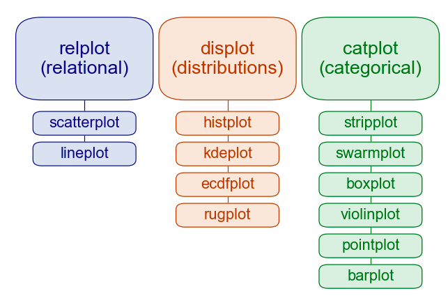

# tips dataset

- dataset for scatter plot

```python
tips = sns.load_dataset("tips")
tips.head()
```

```
##    total_bill   tip     sex smoker  day    time  size
## 0       16.99  1.01  Female     No  Sun  Dinner     2
## 1       10.34  1.66    Male     No  Sun  Dinner     3
## 2       21.01  3.50    Male     No  Sun  Dinner     3
## 3       23.68  3.31    Male     No  Sun  Dinner     2
## 4       24.59  3.61  Female     No  Sun  Dinner     4
```

- if you have trouble load the dataset, try the following code

```
import ssl
ssl._create_default_https_context = ssl._create_unverified_context
```

# relplot (scatter plot)

- scatter plot:
  - data: a dataframe
  - x: x axis
  - y: y axis
- implementation:
  - sns.relplot with kind: scatter (default)
  - sns.scatterplot

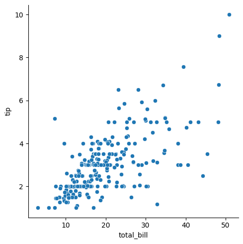

```python
sns.relplot(data=tips,x="total_bill", y="tip", kind='scatter')
# sns.scatterplot(data=tips, x="total_bill", y="tip", )
```

# color and style

- hue: Grouping variable that will produce elements with different colors

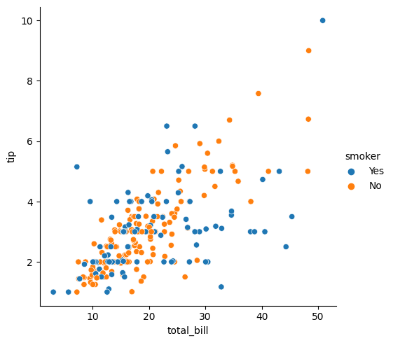

```python
sns.relplot(data=tips,x="total_bill", y="tip", hue = "smoker")
```

- style: shape of the points

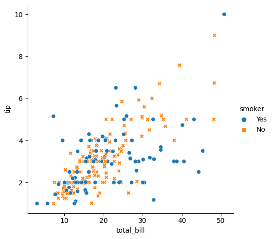

```python
sns.relplot(data=tips,x="total_bill", y="tip", hue = "smoker", style="smoker")
```

# size and transparency

- size: size of points

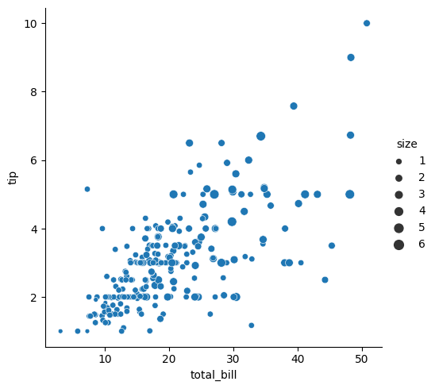

```python
sns.relplot(data=tips,x="total_bill", y="tip", size = "size")
```

- alpha: transparency

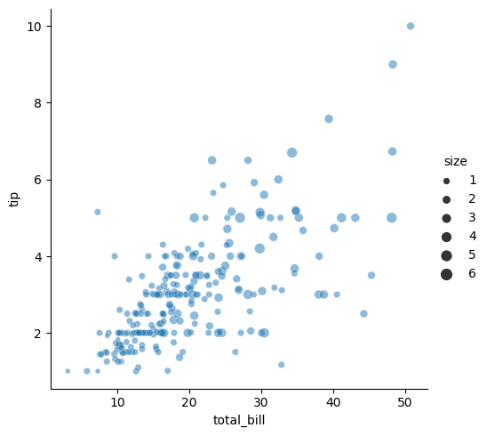

```python
sns.relplot(data=tips,x="total_bill", y="tip", size = "size", alpha = 0.5)
```

# multiple subfigures

- col: columns

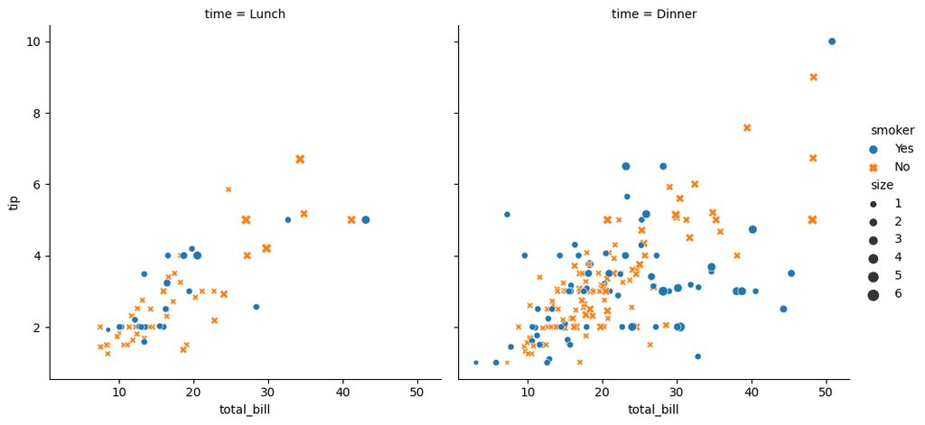

```python
sns.relplot(
    data=tips,
    x="total_bill", y="tip", col="time",
    hue="smoker", style="smoker", size="size",
)
```

# scatter plot with linear regression fitting

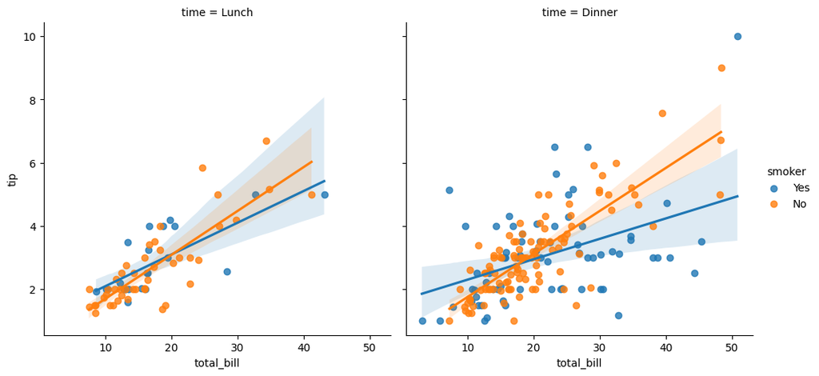

```python
sns.lmplot(data=tips, x="total_bill", y="tip", col="time", hue="smoker")
```

# styles

- There are 5 built-in styles
  - darkgrid (default)
  - whitegrid
  - dark
  - white
  - ticks

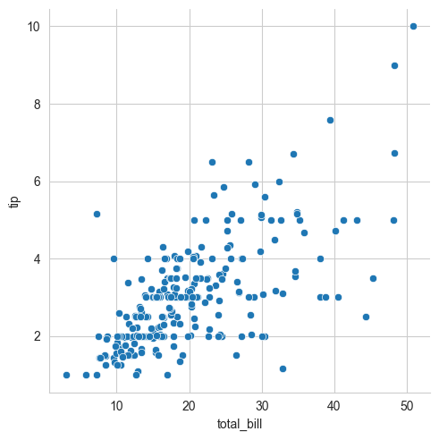

```python
sns.set_style("whitegrid")
sns.relplot(data=tips,x="total_bill", y="tip", kind='scatter')
```

alternative function:

```
sns.set_theme(style = "whitegrid")
```

# Scaling Plots – set_context

- There are 4 built-in context (related to font size)
  - notebook (default)
  - paper
  - talk
  - poster

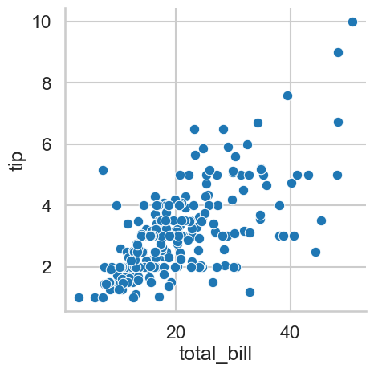

```python
sns.set_style("whitegrid")
sns.set_context("talk")
sns.relplot(data=tips,x="total_bill", y="tip", kind='scatter')
```

alternative function:

```
sns.set_theme(context = "talk, style = "whitegrid")
```

# fmri dataset

- dataset for line plot

```python
fmri = sns.load_dataset("fmri")
fmri.head()
```

```
##   subject  timepoint event    region    signal
## 0     s13         18  stim  parietal -0.017552
## 1      s5         14  stim  parietal -0.080883
## 2     s12         18  stim  parietal -0.081033
## 3     s11         18  stim  parietal -0.046134
## 4     s10         18  stim  parietal -0.037970
```

```python
fmri_sub13 = fmri[(fmri["subject"]=="s13")]
fmri_sub13_stim = fmri_sub13[(fmri_sub13["event"]=="stim")]
fmri_sub13_stim_parietal = fmri_sub13_stim[(fmri_sub13_stim["region"]=="parietal")]
fmri_sub13_stim_parietal.head()
```

```
##    subject  timepoint event    region    signal
## 0      s13         18  stim  parietal -0.017552
## 15     s13         17  stim  parietal -0.008265
## 29     s13         16  stim  parietal -0.002856
## 43     s13         15  stim  parietal -0.010971
## 57     s13         14  stim  parietal -0.033713
```

# relplot (line plot)

- line plot:
  - data: a dataframe
  - x: x axis
  - y: y axis
- implementation:
  - sns.relplot with kind = line
  - sns.lineplot

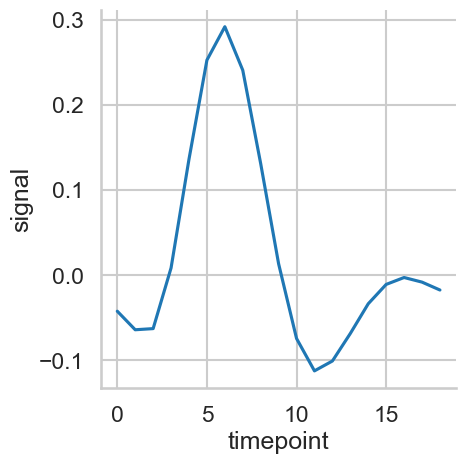

```python
sns.relplot(data=fmri_sub13_stim_parietal, kind="line", x="timepoint", y="signal")
# sns.lineplot(data=fmri_sub13_stim_parietal, x="timepoint", y="signal")
```

# combine scatter and line plots

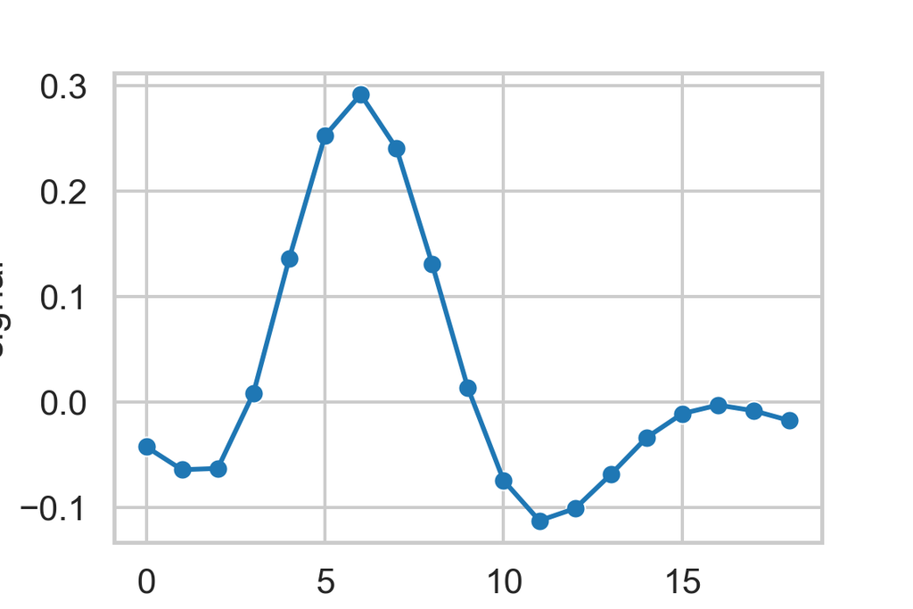

```python
fig, ax = plt.subplots(figsize=(6, 4))
sns.scatterplot(data=fmri_sub13_stim_parietal, x="timepoint", y="signal", ax=ax)
sns.lineplot(data=fmri_sub13_stim_parietal, x="timepoint", y="signal", ax=ax)
```

# relplot (line plot)

- line plot:
  - hue: Grouping variable that will produce elements with different colors
  - style: shape
  - size: size
  - col: columns
- color by hue

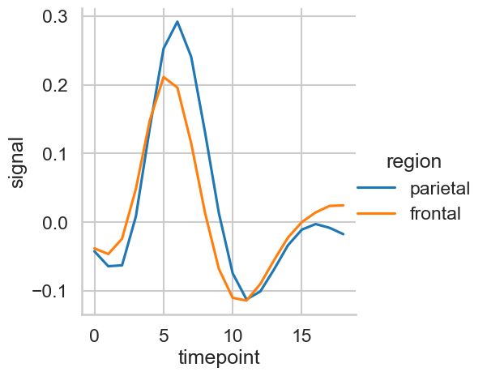

```python
sns.relplot(data=fmri_sub13_stim, kind="line", x="timepoint", y="signal", hue="region", )
```

- style

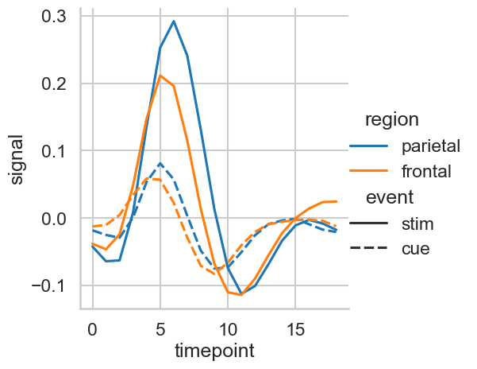

```python
sns.relplot(data=fmri_sub13, kind="line", x="timepoint", y="signal", hue="region", style = "event", )
```

- columns

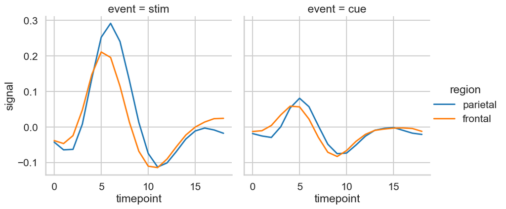

```python
sns.relplot(data=fmri_sub13, kind="line", x="timepoint", y="signal", hue="region", col="event", )
```

# multiple subjects

- If multiple data exist for the same data points, the mean value and the confidence interval will be plotted

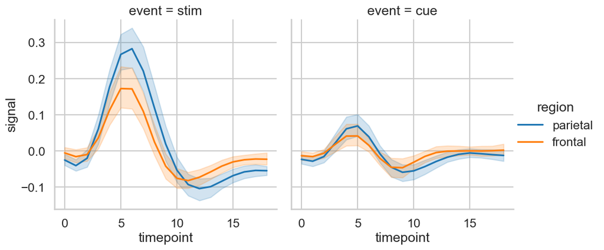

```python
sns.relplot(data=fmri, kind="line", x="timepoint", y="signal", hue="region", col="event", )
```

# Exercise

- based on the following fmri sub dataset, draw a spaghetti plot of signal with respect to time point for each subject

```python
fmri_sub = fmri[(fmri["event"]=="stim") & (fmri["region"]=="parietal")]
fmri_sub.head()
```

```
##   subject  timepoint event    region    signal
## 0     s13         18  stim  parietal -0.017552
## 1      s5         14  stim  parietal -0.080883
## 2     s12         18  stim  parietal -0.081033
## 3     s11         18  stim  parietal -0.046134
## 4     s10         18  stim  parietal -0.037970
```

- solution

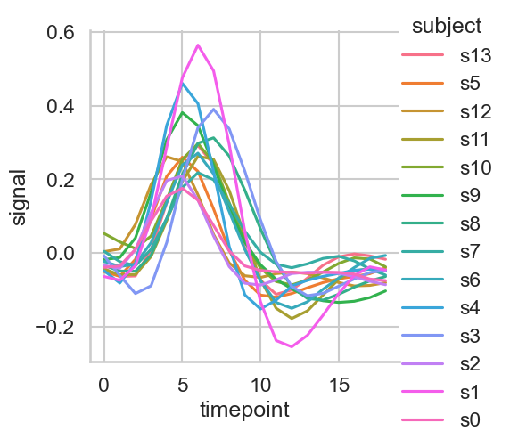

```python
sns.relplot(data=fmri_sub, kind="line", x="timepoint", y="signal", hue="subject", )
```

# histogram

- sns.displot
  - kind=“hist” by default
  - kind=“kde”: kernal density estimation
  - kind=“ecdf”: emperical cdf

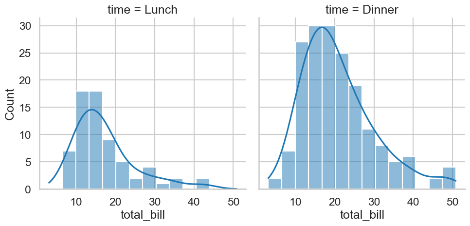

```python
# sns.displot(data=tips, x="total_bill")
sns.displot(data=tips, x="total_bill", col="time", kde=True)
## density function only
## sns.displot(data=tips, x="total_bill", col="time", kind = "kde")
```

# empirical cumulative distribution function

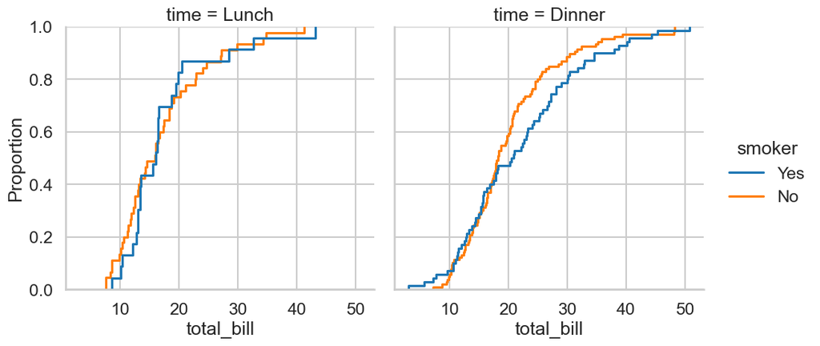

```python
sns.displot(data=tips, kind="ecdf", x="total_bill", col="time", hue="smoker")
```

- rug: show each observation with marginal ticks

```
# sns.displot(data=tips, kind="ecdf", x="total_bill", col="time", hue="smoker", rug=True)
```

# Visualizing categorical data

- Categorical scatterplots:
  - stripplot() (with kind=“strip”; the default)
  - swarmplot() (with kind=“swarm”)
- Categorical distribution plots:
  - boxplot() (with kind=“box”)
  - violinplot() (with kind=“violin”)
- Categorical estimate plots:
  - pointplot() (with kind=“point”)
  - barplot() (with kind=“bar”)
  - countplot() (with kind=“count”)

# catplot (strip plot)

- strip plot: jitter plot

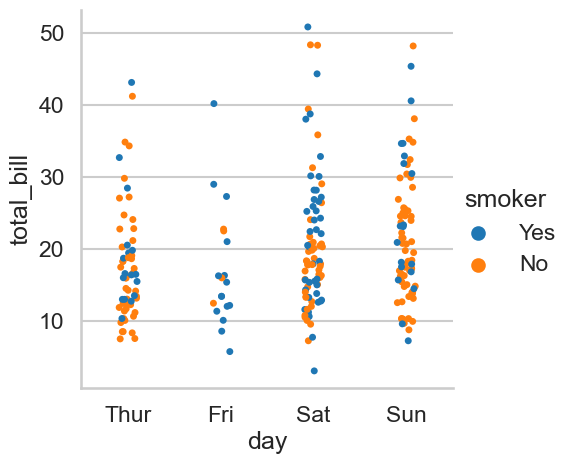

```python
sns.catplot(data=tips, kind="strip", x="day", y="total_bill", hue="smoker")
```

```
sns.catplot(data=tips, kind="strip", x="day", y="total_bill", hue="smoker", dodge=True)
sns.stripplot(data=tips, x="day", y="total_bill", hue="smoker")
```

# catplot (swarm plot)

- swarm plot

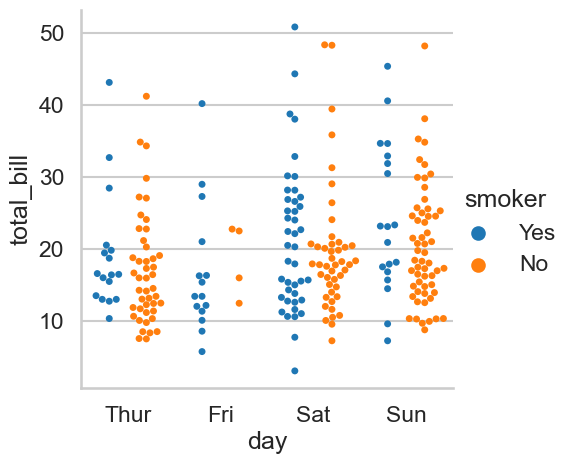

```python
sns.catplot(data=tips, kind="swarm", x="day", y="total_bill", hue="smoker", dodge=True)
```

```
sns.catplot(data=tips, kind="swarm", x="day", y="total_bill", hue="smoker", )
sns.swarmplot(data=tips, x="day", y="total_bill", hue="smoker")
```

# catplot (boxplot)

- boxplot
  - sns.catplot with kind = “box”
  - sns.boxplot

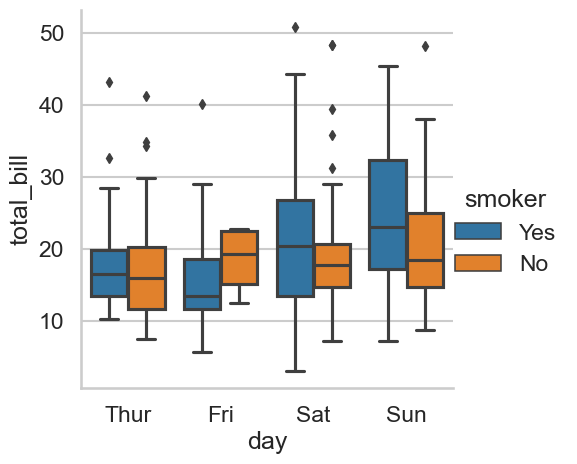

```python
sns.catplot(data=tips, kind="box", x="day", y="total_bill", hue="smoker")
# sns.boxplot(data=tips, x="day", y="total_bill", hue="smoker")
```

# overlay box plot and jitter plot

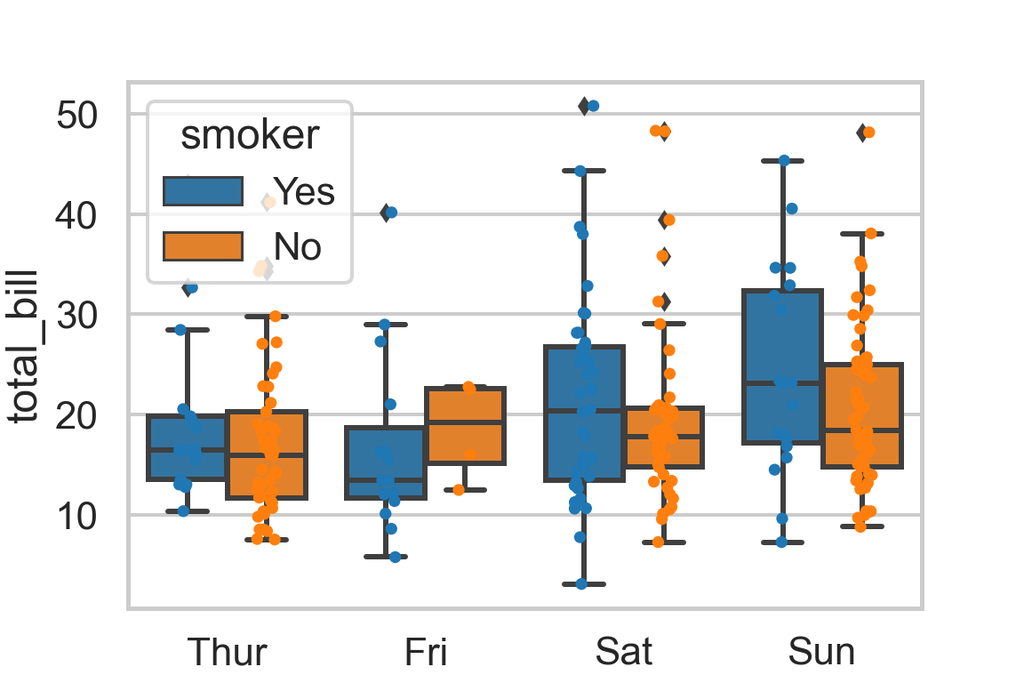

```python
fig, ax = plt.subplots(figsize=(6, 4))
sns.stripplot(data=tips, x="day", y="total_bill", hue="smoker", dodge=True, ax=ax, legend=False)
sns.boxplot(data=tips, x="day", y="total_bill", hue="smoker", ax=ax)
```

# catplot (violin)

- violin
  - sns.catplot with kind = “violin”
  - sns.violinplot

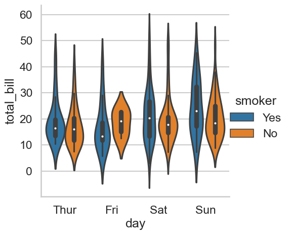

```python
sns.catplot(data=tips, kind="violin", x="day", y="total_bill", hue="smoker")
# sns.violinplot(data=tips, x="day", y="total_bill", hue="smoker")
```

# catplot (pointplot)

- pointplot: point estimate + error bar
  - sns.catplot with kind = “point”
  - sns.pointplot

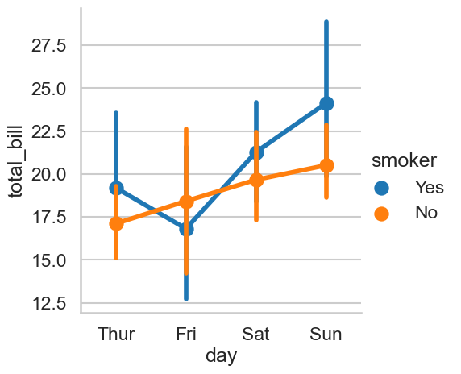

```python
sns.catplot(data=tips, kind="point", x="day", y="total_bill", hue="smoker")
# sns.pointplot(data=tips, x="day", y="total_bill", hue="smoker")
```

# catplot (barplot)

- barplot:
  - sns.catplot with kind = “bar”
  - sns.barplot

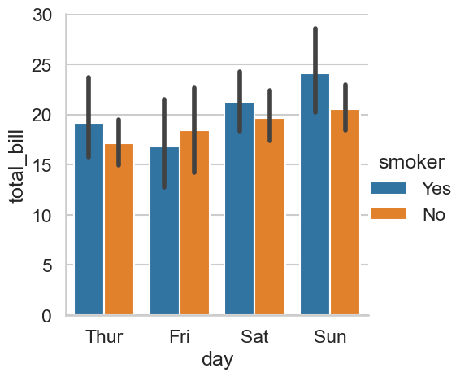

```python
sns.catplot(data=tips, kind="bar", x="day", y="total_bill", hue="smoker")
# sns.barplot(data=tips, x="day", y="total_bill", hue="smoker")
# sns.barplot(data=tips, x="day", y="total_bill", hue="smoker", ci=None)
# sns.barplot(data=tips, y="day", x="total_bill", hue="smoker") ## horizontal barplot
```

# catplot (countplot)

- countplot
  - sns.catplot with kind = “count”
  - sns.countplot

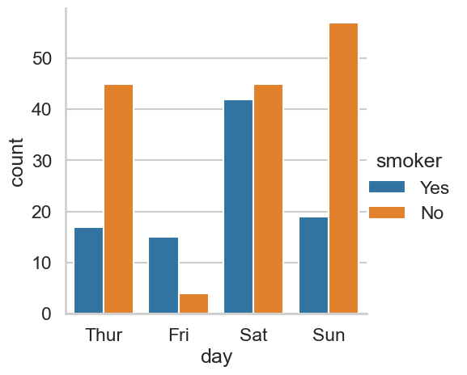

```python
sns.catplot(data=tips, kind="count", x="day", hue="smoker")
# sns.countplot(data=tips, x="day", hue="smoker")
```

# iris dataset

- dataset for heatmap and pairplot

```python
iris = sns.load_dataset("iris")
iris.head()
```

```
##    sepal_length  sepal_width  petal_length  petal_width species
## 0           5.1          3.5           1.4          0.2  setosa
## 1           4.9          3.0           1.4          0.2  setosa
## 2           4.7          3.2           1.3          0.2  setosa
## 3           4.6          3.1           1.5          0.2  setosa
## 4           5.0          3.6           1.4          0.2  setosa
```

# pairplot

- to visualize the relationship between each pair of numerical variable

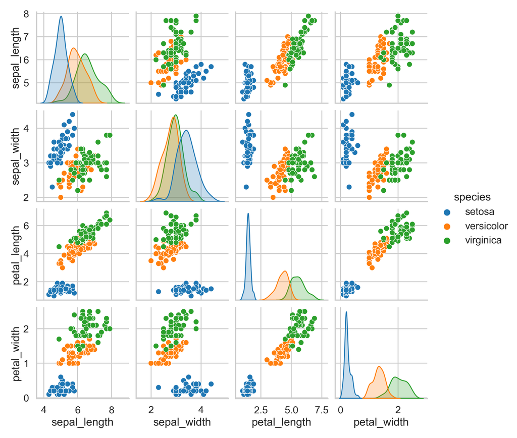

```python
p1 = sns.pairplot(iris, hue="species")
#sns.pairplot(iris)
plt.show()
```

# heatmap

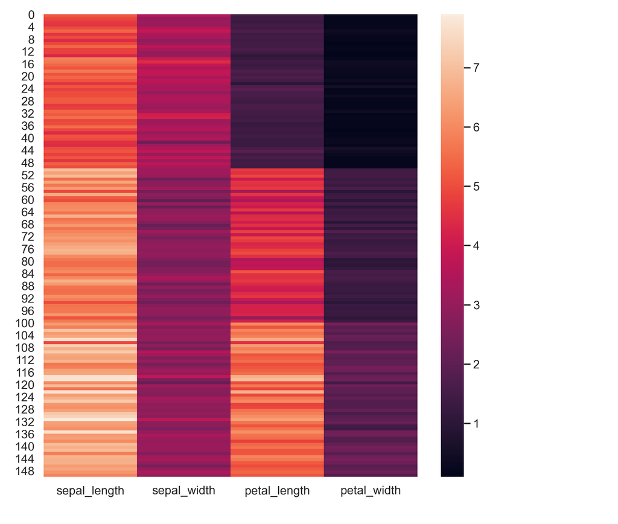

```python
iris_sub = iris.drop(columns="species")
sns.heatmap(iris_sub)
```

# Reference

https://seaborn.pydata.org/tutorial